# Enterotype Data Stratified by Enterotype

12/01/2016 - 16:55:34

This is the R Markdown report containing inputs and outputs coming from the Shiny application for determining power and sample sizes of case-control microbiome studies. Markdown is a simple formatting syntax for authoring HTML, PDF, and MS Word documents. For more details on using R Markdown see http://rmarkdown.rstudio.com.

## INPUTS

| Description | Value | Description | Value |
| --- | --- | --- | --- |
| Stratification | YES | Sample 1 Size | 40 |
| MonteCarlo Repl.s | 1000 | Sample 2 Size | 40 |
| Pi-One type | StoolEntero | Min Sample Size | 30 |
| Number of OTUs | 50 | Max Sample Size | 70 |
| Changed OTUs 1 | 2 | Rel. Abund. Diff. 1 | 20 % |
| Changed OTUs 2 | 2 | Rel. Abund. Diff. 2 | 40 % |
| Most/Least Abundant 1 | most abundant | Significance Level | 0.1 |
| Most/Least Abundant 2 | most abundant |  |  |

Theta parameter instead is.

```
##  Bacteroides   Prevotella Ruminococcus
##        0.052        0.054        0.051
```

## OUTPUTS

### Settings graphs

The following graphs show desired relative abundance distributions with their respective estimates based on the two simulated samples of size 40 and 40, respectively.

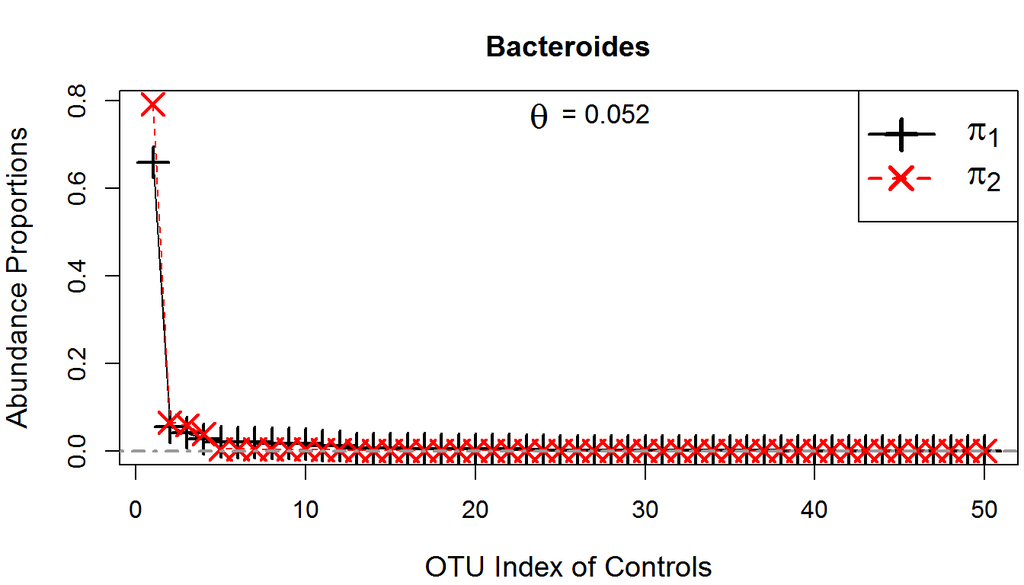

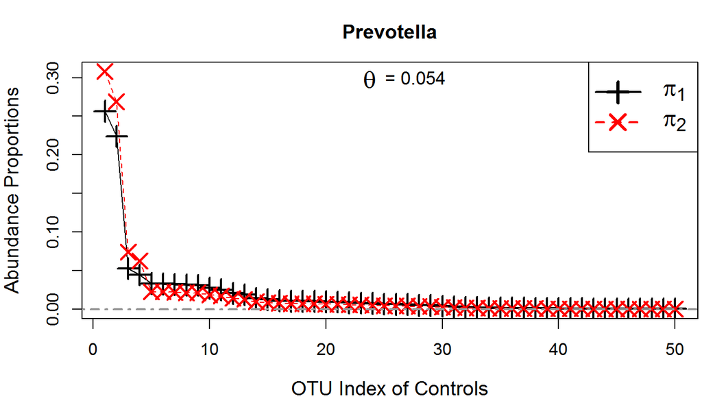

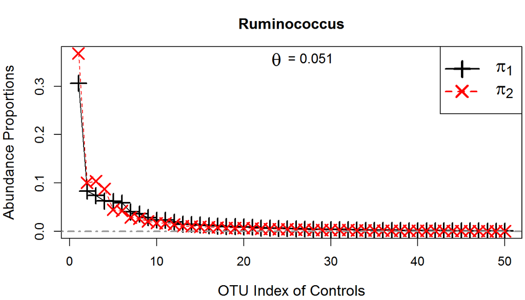

### Library Size Distribution

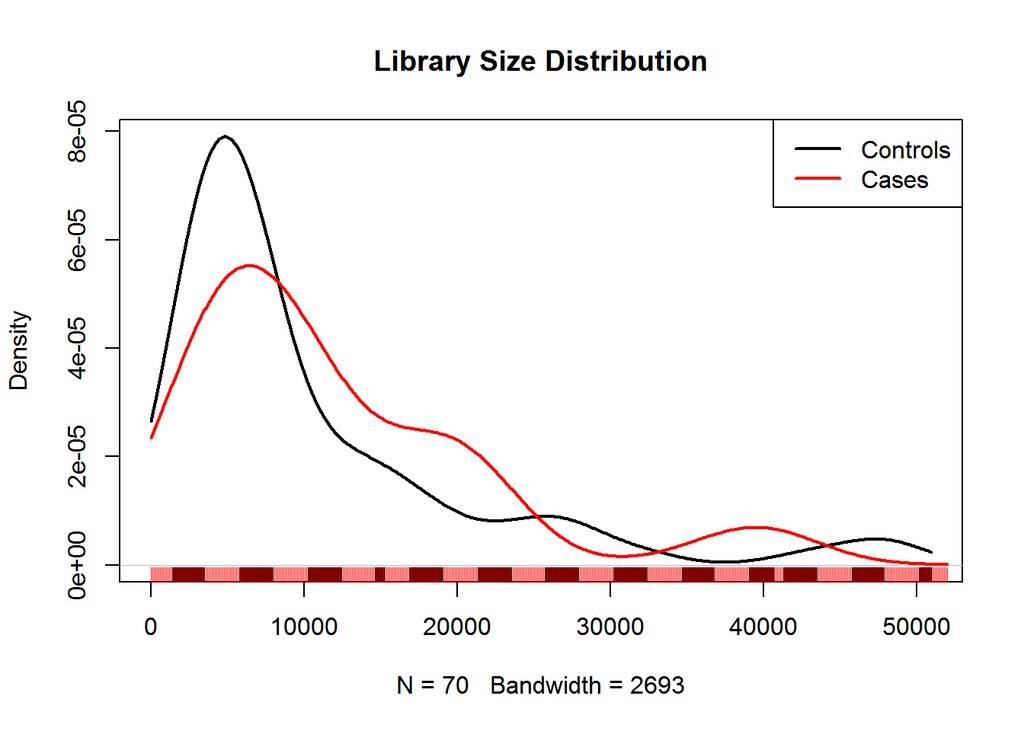

### Power simulation with current settings

Power results for the current settings:

```
##               Wald   WMW WMW avg
## Bacteroides  0.648 0.513   0.158
## Prevotella   0.054 0.137   0.037
## Ruminococcus 0.065 0.115   0.031
## Global       0.393 0.940   0.423
```

### Power and sample size graph

The next graph shows the **power** *vs.* the **sample size** behaviour where the latter goes from 30 to 70.

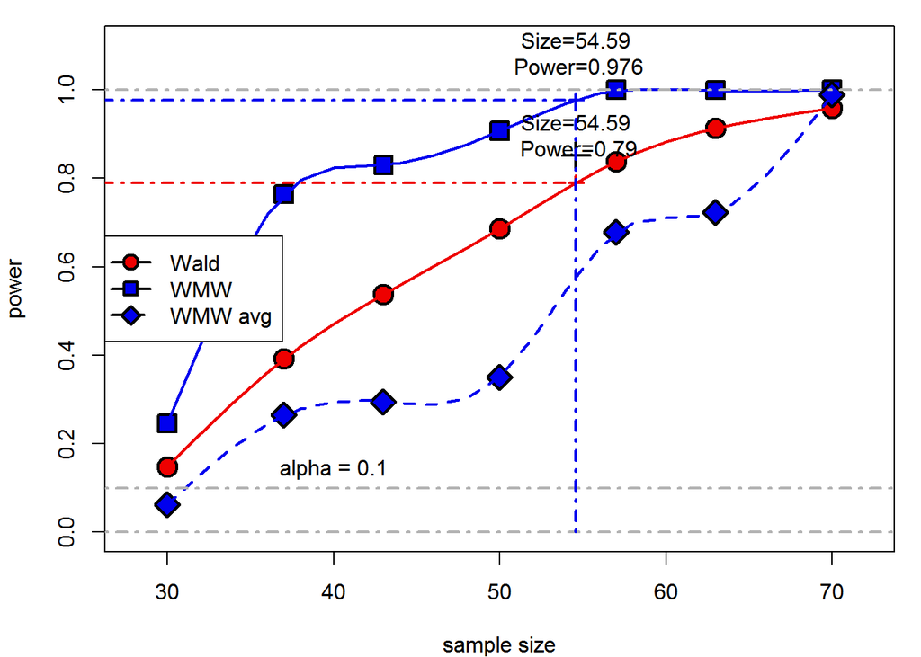

### Power of individual OTUs

The following table appears only in case WMW test was selected. Column **Type** indicates the type of the OTU:

- type2DA: second type of Differentially Abundant OTUs, the ones with the bigger default effect size (percentage increase);
- type1DA: first type of Differentially Abundant OTUs, the ones with the smaller default effect size.

| Bacteroides.ID | Bacteroides.Power | Type |
| --- | --- | --- |
| Bacteria.Bacteroidetes.Bacteroidia.Bacteroidales.Bacteroidaceae.Bacteroides | 0.660 | type2DA |
| Bacteria.Bacteroidetes.Bacteroidia.Bacteroidales.Porphyromonadaceae.Parabacteroides | 0.055 | type2DA |
| Bacteria.Bacteroidetes.Bacteroidia.Bacteroidales.Rikenellaceae.Alistipes | 0.042 | type1DA |
| Bacteria.Firmicutes.Clostridia.Clostridiales.Lachnospiraceae.unclassified | 0.027 | type1DA |

| Prevotella.ID | Prevotella.Power | Type |
| --- | --- | --- |
| Bacteria.Bacteroidetes.Bacteroidia.Bacteroidales.Prevotellaceae.Prevotella | 0.257 | type2DA |
| Bacteria.Bacteroidetes.Bacteroidia.Bacteroidales.Bacteroidaceae.Bacteroides | 0.224 | type2DA |
| Bacteria.Bacteroidetes.Bacteroidia.Bacteroidales.Rikenellaceae.Alistipes | 0.053 | type1DA |
| Bacteria.Bacteroidetes.Bacteroidia.Bacteroidales.Porphyromonadaceae.Parabacteroides | 0.045 | type1DA |

| Ruminococcus.ID | Ruminococcus.Power | Type |
| --- | --- | --- |
| Bacteria.Bacteroidetes.Bacteroidia.Bacteroidales.Bacteroidaceae.Bacteroides | 0.307 | type2DA |
| Bacteria.Firmicutes.Clostridia.Clostridiales.Ruminococcaceae.Faecalibacterium | 0.084 | type2DA |
| Bacteria.Firmicutes.Clostridia.Clostridiales.Ruminococcaceae.unclassified | 0.074 | type1DA |
| Bacteria.Firmicutes.Clostridia.Clostridiales.unclassified | 0.063 | type1DA |

```r
Sys.time()
```

```
## [1] "2016-01-12 16:55:35 CET"
```